# EXPLORATION OF WHITE WINE QUALITY by LAWRENCE V. SUMERA

This project will use R to apply exploratory data analysis techniques to explore relationships in one variable to multiple variables. This also aims to explore a dataset related to white wine variants of the Portugues “Vinho Verde” wine.

The inputs include objective tests such as pH values and the output is based on sensory data (median of at least 3 evaluations made by wine experts). Each expert graded the wine quality between 0 (very bad) and 10 (very excellent). Due to privacy and logistic issues, only physicochemical inputs and sensory output variables are available.

# Univariate Plots Section

```
## [1] 4898   13
```

```
##        X        fixed.acidity    volatile.acidity  citric.acid
##  Min.   :   1   Min.   : 3.800   Min.   :0.0800   Min.   :0.0000
##  1st Qu.:1225   1st Qu.: 6.300   1st Qu.:0.2100   1st Qu.:0.2700
##  Median :2450   Median : 6.800   Median :0.2600   Median :0.3200
##  Mean   :2450   Mean   : 6.855   Mean   :0.2782   Mean   :0.3342
##  3rd Qu.:3674   3rd Qu.: 7.300   3rd Qu.:0.3200   3rd Qu.:0.3900
##  Max.   :4898   Max.   :14.200   Max.   :1.1000   Max.   :1.6600
##  residual.sugar     chlorides       free.sulfur.dioxide
##  Min.   : 0.600   Min.   :0.00900   Min.   :  2.00
##  1st Qu.: 1.700   1st Qu.:0.03600   1st Qu.: 23.00
##  Median : 5.200   Median :0.04300   Median : 34.00
##  Mean   : 6.391   Mean   :0.04577   Mean   : 35.31
##  3rd Qu.: 9.900   3rd Qu.:0.05000   3rd Qu.: 46.00
##  Max.   :65.800   Max.   :0.34600   Max.   :289.00
##  total.sulfur.dioxide    density             pH          sulphates
##  Min.   :  9.0        Min.   :0.9871   Min.   :2.720   Min.   :0.2200
##  1st Qu.:108.0        1st Qu.:0.9917   1st Qu.:3.090   1st Qu.:0.4100
##  Median :134.0        Median :0.9937   Median :3.180   Median :0.4700
##  Mean   :138.4        Mean   :0.9940   Mean   :3.188   Mean   :0.4898
##  3rd Qu.:167.0        3rd Qu.:0.9961   3rd Qu.:3.280   3rd Qu.:0.5500
##  Max.   :440.0        Max.   :1.0390   Max.   :3.820   Max.   :1.0800
##     alcohol         quality
##  Min.   : 8.00   Min.   :3.000
##  1st Qu.: 9.50   1st Qu.:5.000
##  Median :10.40   Median :6.000
##  Mean   :10.51   Mean   :5.878
##  3rd Qu.:11.40   3rd Qu.:6.000
##  Max.   :14.20   Max.   :9.000
```

Our dataset consists of thirteen variables, with exactly 4,898 observations. According to the description of the dataset, there are no missing attribute values.

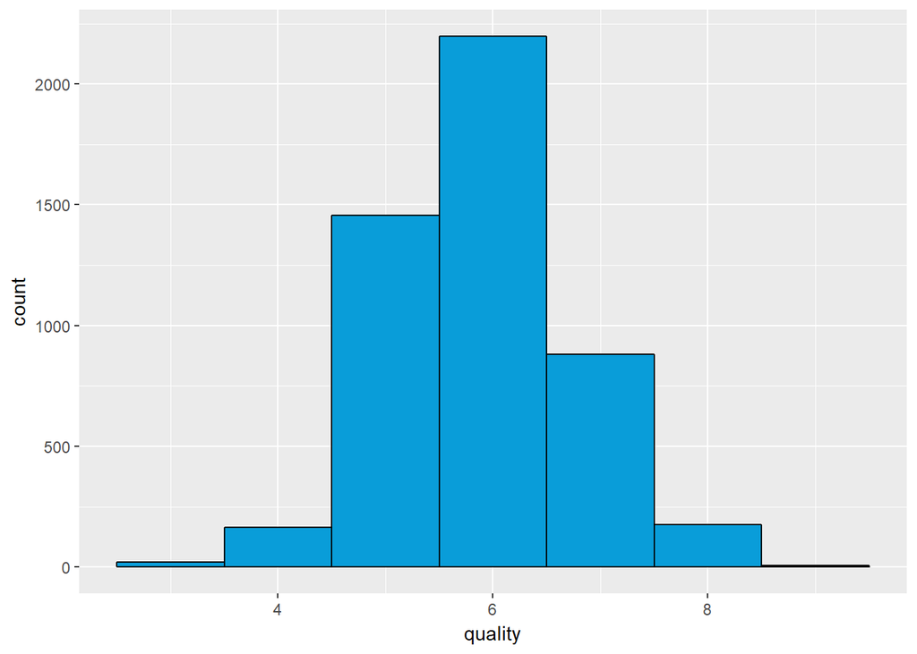

The quality distribution appears normal with very few “bad” and “excellent” quality wines. There are no pathetic 0s and perfect 10s. Most wines range from 5 to 7 on a qualitative scale. I wonder what this plot looks like across the other numerical variables such as alcohol content, sweetness and acidity level.

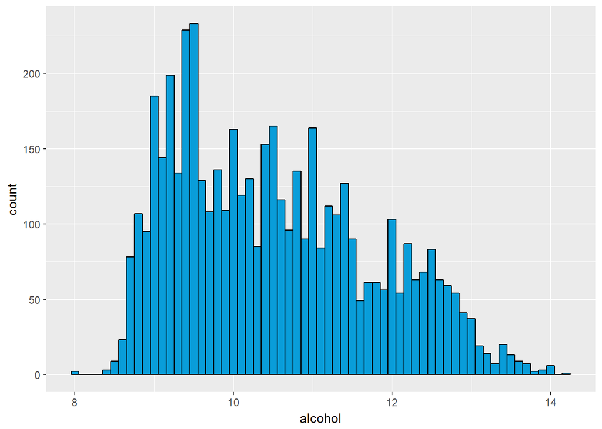

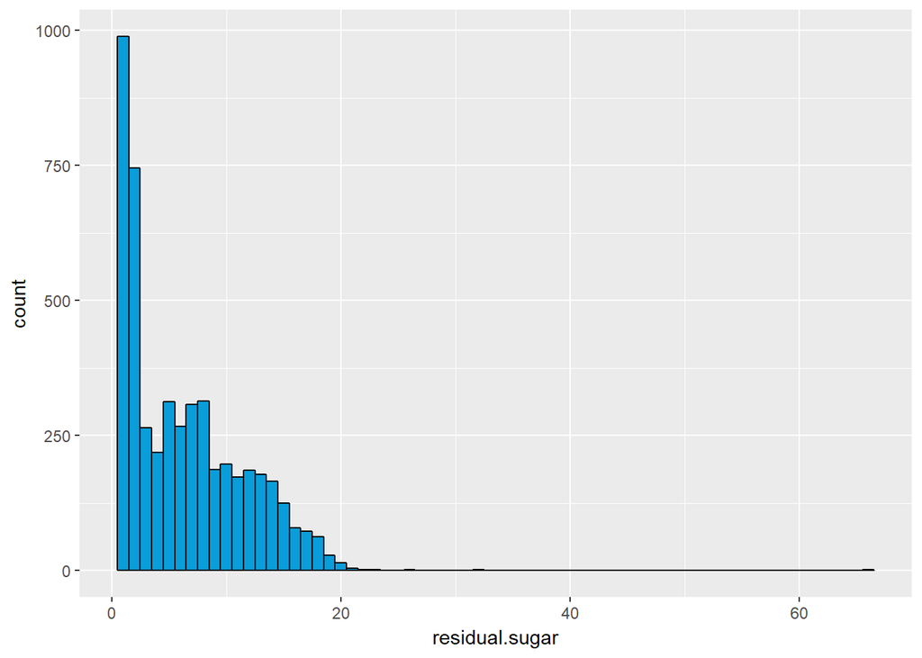

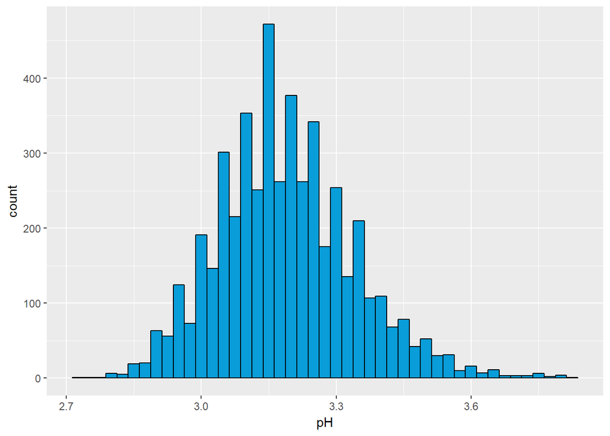

Most wines have a relatively low alcohol content. The distribution seems skewed to the right with a mode of around 9.5% alcohol by volume. A majority of the wines have low residual sugar content. Most, if not all, are considered not sweet since they have less than 45 g/L amount of sugar. As expected, all wines are acidic (< 7 pH). The distribution is normal with most wines having a pH between 3 and 3.4.

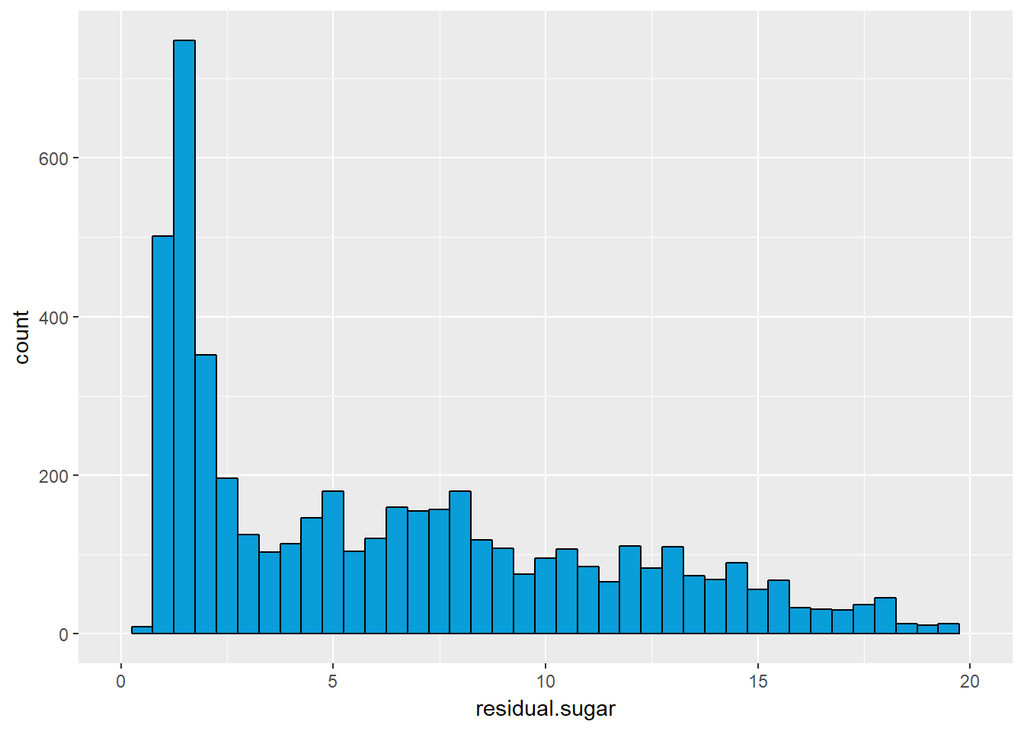

Since we have a few outliers in the residual sugar content histogram, we have zoomed in on the majority of the wines which are not considered sweet. The plot appears skewed to the right. Let’s investigate those sweeter wines not included in this plot and check their quality.

```
##  [1] 6 6 5 5 6 5 6 6 5 6 5 5 5 6 6 6 6 5
```

The relatively sweet wines have a quality of either 5 or 6 only which are considered as normal. I can safely say that the sweeter wine variants do not taste poor but they do not taste excellent as well. Thus, I would like to explore the other variables and check their distributions. Some of the variables may be related to each other.

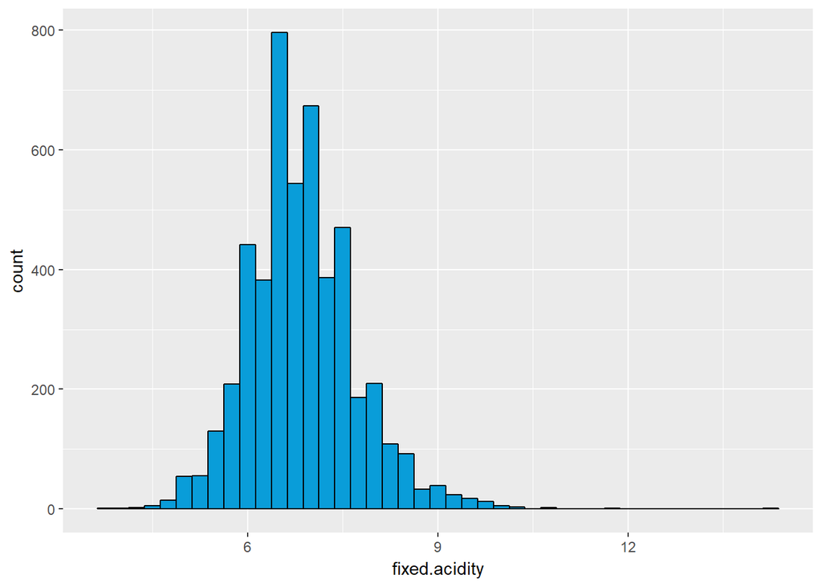

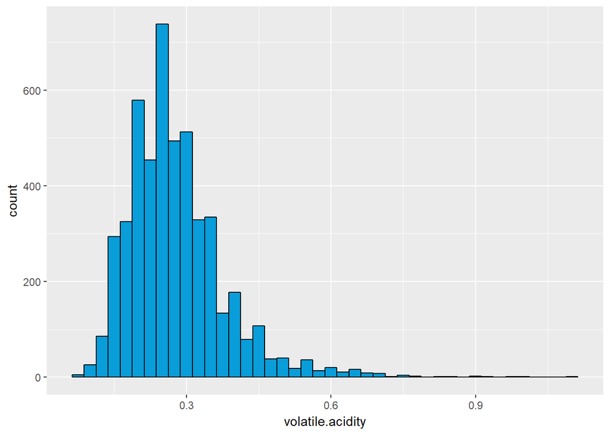

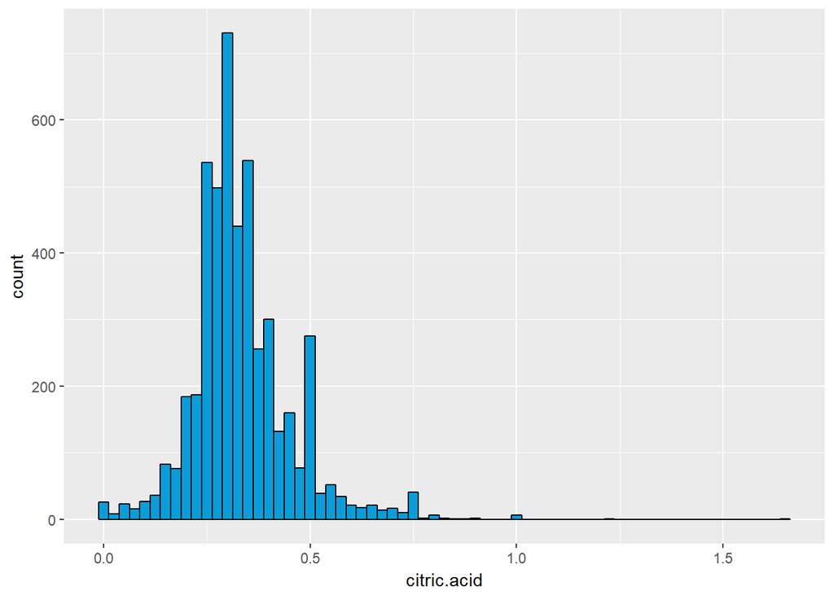

The three variables: fixed acidity, volatile acidity, and citric acid may be related to pH since pH is a measure of how acidic or basic the wine is. Their distributions look normal with a few outliers. pH also has a normal distribution so the assumption is likely correct.

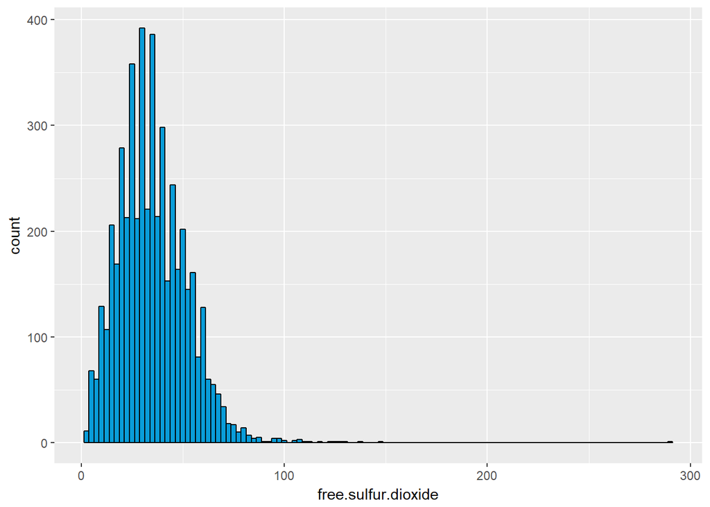

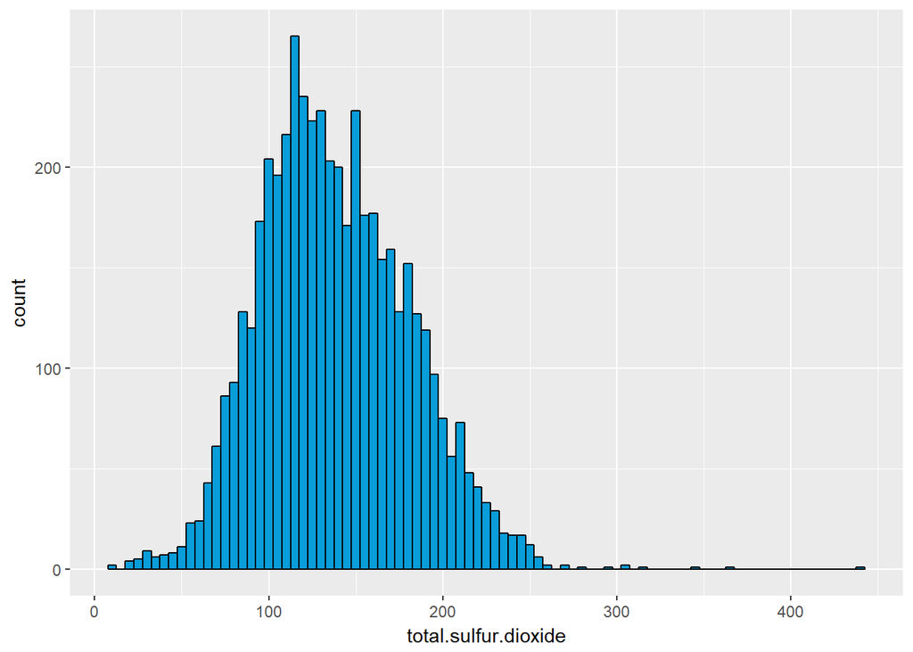

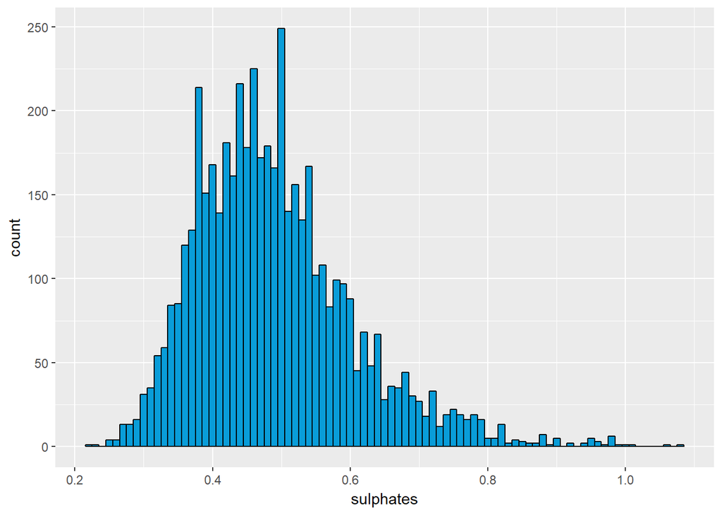

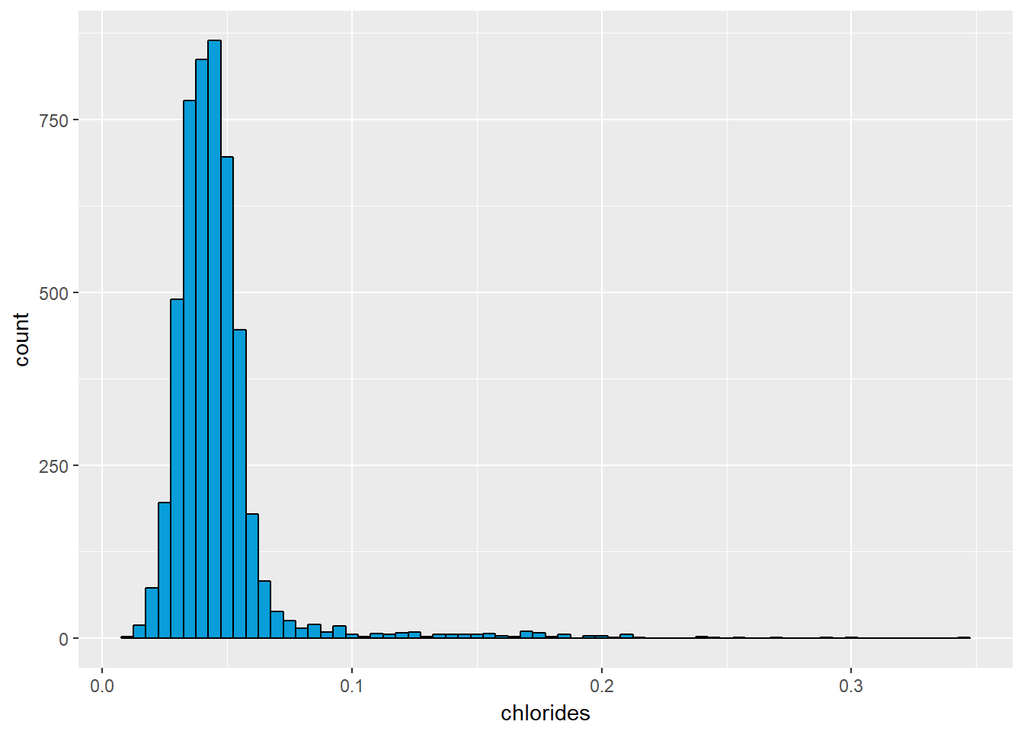

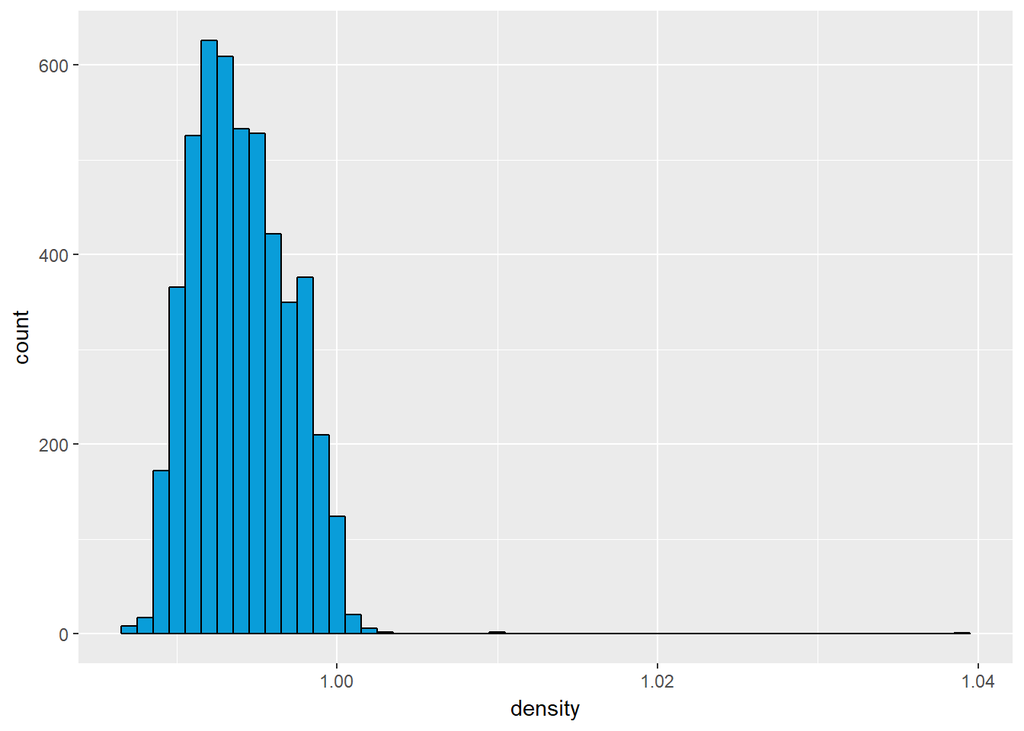

The distribution looks normal with extreme outliers at the right. Those outliers have this mean quality.

```
## [1] 5.495575
```

Again, the mean of those wines is less than normal which means that higher density wines and higher chloride wines have lower quality.

# Univariate Analysis

### What is the structure of your dataset?

There are 4,898 white wines in the dataset with 11 features (fixed acidity, volatile acidity, citric acid, residual sugar, chlorides, free sulfur dioxide, total sulfur dioxide, density, pH, sulphates, alcohol and quality). The output variable (quality) is not an ordered factor variable but since the type is an integer which can be sorted, transformation is not necessary. Quality is a discrete quantitative variable.

The output is the median of at least 3 evaluations made by wine experts. The grade is between 0 (very bad) and 10 (very excellent).

Notable observations: - Most white wines range between 5 to 7 on the quality scale.

- The lowest quality of wine is 3 while the highest is 9.
- Most wines have relatively low alcohol and residual sugar content.
- All wines are acidic (mostly between 3 to 3.4).
- Fixed acidity, volatile acidity, and citric acid content may affect pH.
- Free sulfur dioxide, total sulfur dioxide and sulphates may be related.
- Chlorides content may affect quality.

### What is/are the main feature(s) of interest in your dataset?

The main features in the data set are alcohol content and quality. I would like to determine which chemical properties influence the quality of white wines. I suspect alcohol content and some combination of other variables can be used to build a predictive model to grade white wine quality.

### What other features in the dataset do you think will help support your investigation into your feature(s) of interest?

Residual sugar and pH may also likely contribute to the quality of the white wine. It was interesting to observe that some of the other variables are related and looking at them individually may give understanding to some of the chemical properties influencing the quality.

### Did you create any new variables from existing variables in the dataset?

There is potential to create new variables from the existing variables. For example, fixed acidity, volatile acidity and citric acid can be added to create a new variable to measure the total acid content of the wine using a single variable. Conversely, a new variable called bound sulfur dioxide may be created by subtracting total sulfur dioxide with the free sulfur dioxide. Residual sugar and chlorides may be added to check the combined effect of salt and sugar in the quality.

These methods may be explored further once I dive deeper into bivariate analysis.

### Of the features you investigated, were there any unusual distributions? Did you perform any operations on the data to tidy, adjust, or change the form of the data? If so, why did you do this?

Most distributions were normal except for alcohol and residual sugar. The data set is already considered as tidy. Plus, there are no missing variables. Cleaning the data was no longer necessary.

# Bivariate Plots Section

```
##                           X fixed.acidity volatile.acidity citric.acid
## X                     1.000        -0.256            0.003      -0.150
## fixed.acidity        -0.256         1.000           -0.023       0.289
## volatile.acidity      0.003        -0.023            1.000      -0.149
## citric.acid          -0.150         0.289           -0.149       1.000
## residual.sugar        0.007         0.089            0.064       0.094
## chlorides            -0.046         0.023            0.071       0.114
## free.sulfur.dioxide  -0.012        -0.049           -0.097       0.094
## total.sulfur.dioxide -0.162         0.091            0.089       0.121
## density              -0.186         0.265            0.027       0.150
## pH                   -0.116        -0.426           -0.032      -0.164
## sulphates             0.010        -0.017           -0.036       0.062
## alcohol               0.214        -0.121            0.068      -0.076
## quality               0.036        -0.114           -0.195      -0.009
##                      residual.sugar chlorides free.sulfur.dioxide
## X                             0.007    -0.046              -0.012
## fixed.acidity                 0.089     0.023              -0.049
## volatile.acidity              0.064     0.071              -0.097
## citric.acid                   0.094     0.114               0.094
## residual.sugar                1.000     0.089               0.299
## chlorides                     0.089     1.000               0.101
## free.sulfur.dioxide           0.299     0.101               1.000
## total.sulfur.dioxide          0.401     0.199               0.616
## density                       0.839     0.257               0.294
## pH                           -0.194    -0.090              -0.001
## sulphates                    -0.027     0.017               0.059
## alcohol                      -0.451    -0.360              -0.250
## quality                      -0.098    -0.210               0.008
##                      total.sulfur.dioxide density     pH sulphates alcohol
## X                                  -0.162  -0.186 -0.116     0.010   0.214
## fixed.acidity                       0.091   0.265 -0.426    -0.017  -0.121
## volatile.acidity                    0.089   0.027 -0.032    -0.036   0.068
## citric.acid                         0.121   0.150 -0.164     0.062  -0.076
## residual.sugar                      0.401   0.839 -0.194    -0.027  -0.451
## chlorides                           0.199   0.257 -0.090     0.017  -0.360
## free.sulfur.dioxide                 0.616   0.294 -0.001     0.059  -0.250
## total.sulfur.dioxide                1.000   0.530  0.002     0.135  -0.449
## density                             0.530   1.000 -0.094     0.074  -0.780
## pH                                  0.002  -0.094  1.000     0.156   0.121
## sulphates                           0.135   0.074  0.156     1.000  -0.017
## alcohol                            -0.449  -0.780  0.121    -0.017   1.000
## quality                            -0.175  -0.307  0.099     0.054   0.436
##                      quality
## X                      0.036
## fixed.acidity         -0.114
## volatile.acidity      -0.195
## citric.acid           -0.009
## residual.sugar        -0.098
## chlorides             -0.210
## free.sulfur.dioxide    0.008
## total.sulfur.dioxide  -0.175
## density               -0.307
## pH                     0.099
## sulphates              0.054
## alcohol                0.436
## quality                1.000
```

The correlation matrix validates the initial assumptions made from the univariate analysis. Alcohol has the strongest correlation among the other variables. Density has the second strongest correlation but it is also highly correlated to alcohol. I know that higher alcohol content leads to a lower density because alcohol is lighter than water. Residual sugar also has an effect on density, with more quantities leading to denser wines.

Among the three measures of acid content, fixed acidity has the strongest correlation with pH because its value is significantly much higher as well. I know that the more acidic the wine is, the lower its pH. As expected, free sulfur dioxide is highly correlated to total sulfur dioxide.

There are some surprises. I was not expecting chlorides to have a strong correlation. Residual sugar has a lower correlation with quality than chlorides. The rest of the correlations can be shown in a scatterplot matrix below.

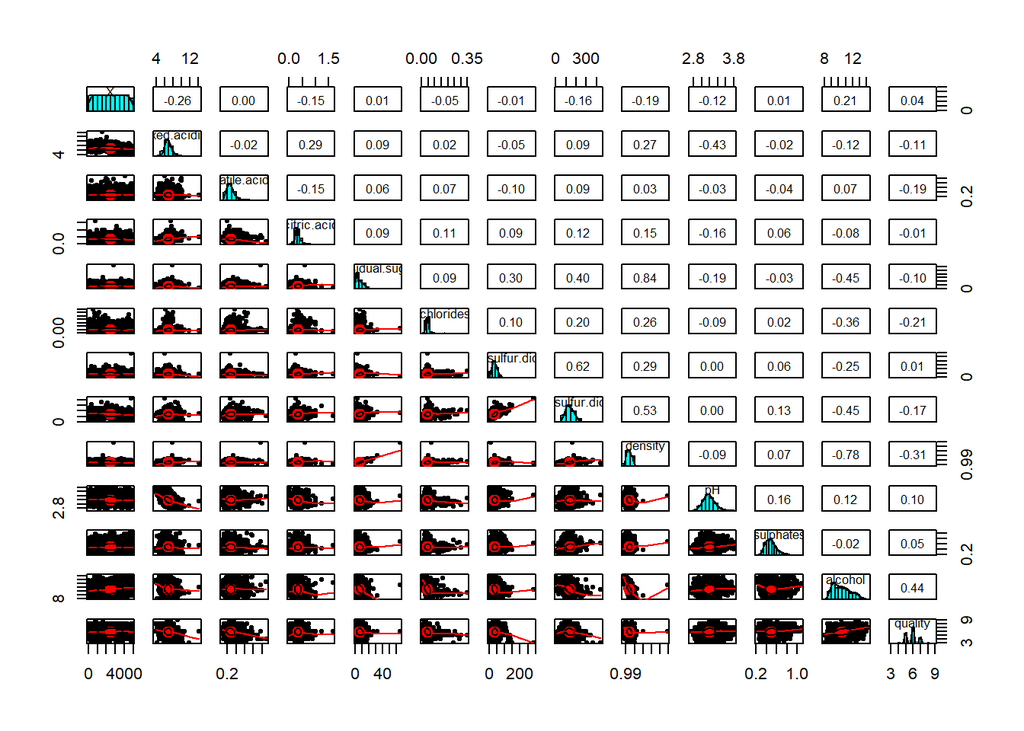

The scatterplots shown in the lower portion of the matrix will be examined further in the next plots.

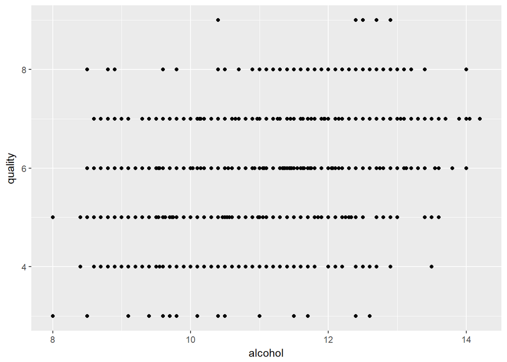

Since quality is of integer type, the scatterplot only shows discrete points at each quality against alcohol. It is difficult to gain an insight on the trend for alcohol versus quality. The plot can be improved by using jitter to spread the data and by introducing a linear model.

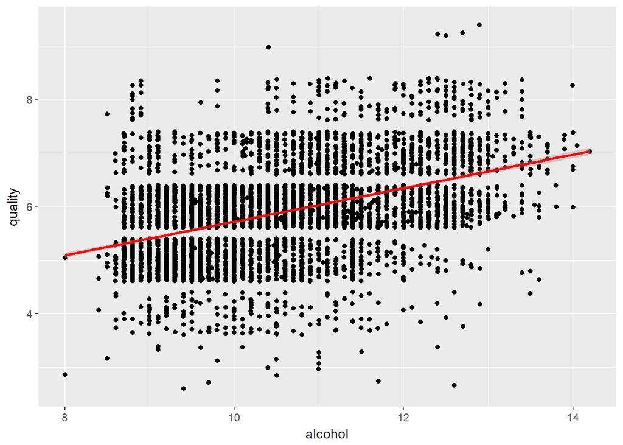

```
##
##  Pearson's product-moment correlation
##
## data:  alcohol and quality
## t = 33.858, df = 4896, p-value < 2.2e-16
## alternative hypothesis: true correlation is not equal to 0
## 95 percent confidence interval:
##  0.4126015 0.4579941
## sample estimates:
##       cor
## 0.4355747
```

The scatter plot shows that the higher alcohol wines tend to have higher qualities as well. The line shows a slightly positive slope which means as alcohol content increases, wine quality also increases. The Pearson’s correlation is also shown. Based on the R^2 value, alcohol explains about 19% of the variance in quality. Next, I can compare median alcohol content against the quality using box plots.

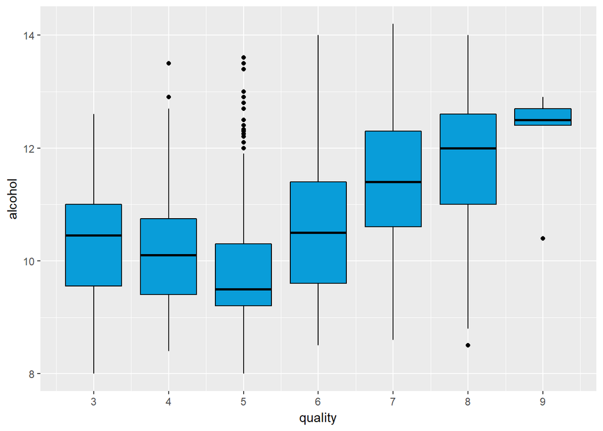

The box plots clearly show that higher quality wines have higher alcohol content. I know that density is correlated with alcohol content so I want to see the scatterplot as well.

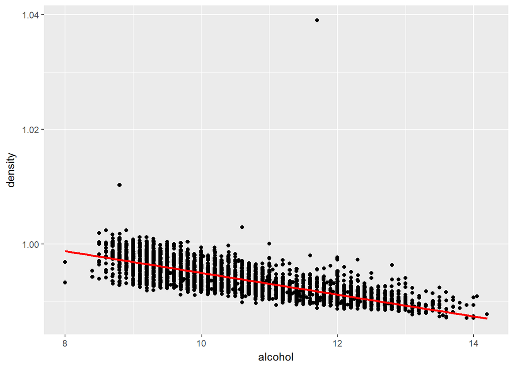

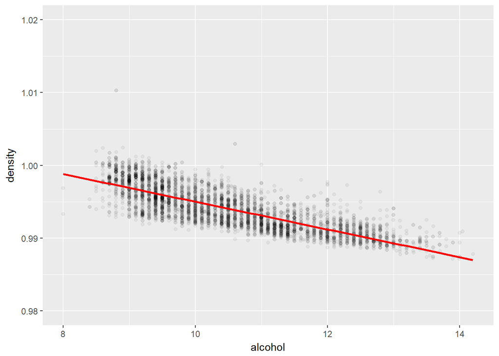

The first plot suffers from overplotting and outliers. The second plot fixes it by introducing an alpha value and removing the outliers from the plot. For simplicity, density is a linear function of alcohol content. There exists a much more complex relationship of alcohol content and density but this will be reserved for higher chemistry courses. Another variable which affects density is residual sugar as shown in the plot below. Again, I have removed the outliers.

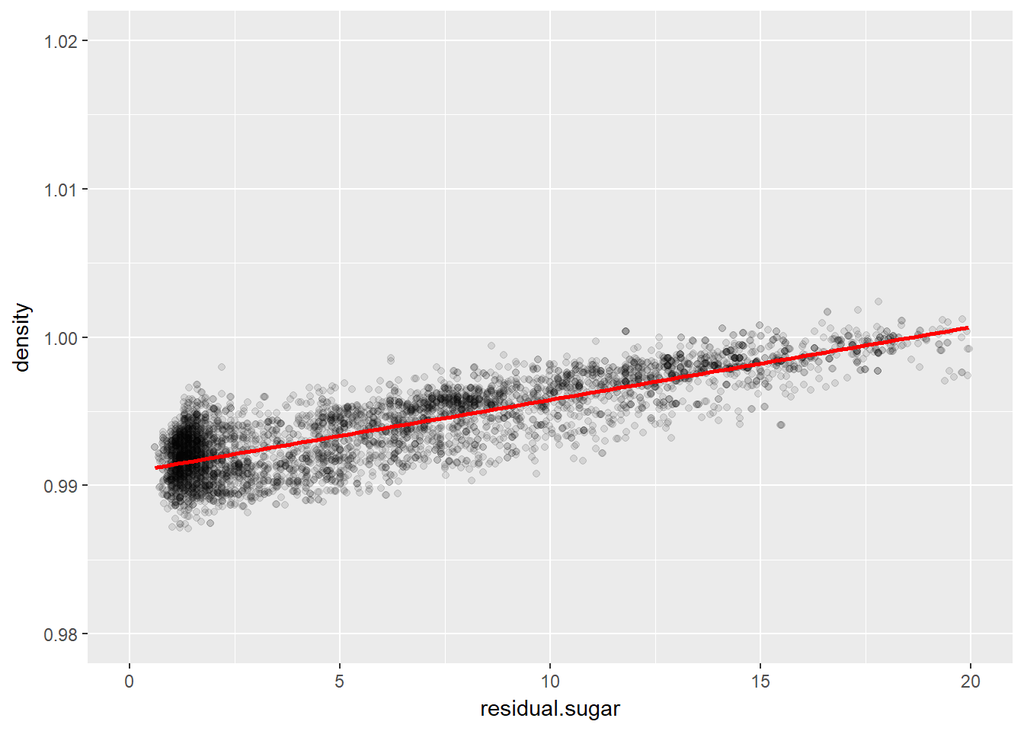

Density is also a linear function of residual sugar. Naturally, the higher the amount of sugar, the heavier or denser the wine becomes. Since density is highly correlated with alcohol content and residual sugar, we can safely say that density does not directly affect quality since it is just an effect of other input variables. However, I want to examine the the amount of residual sugar and pH to see if they affect the quality.

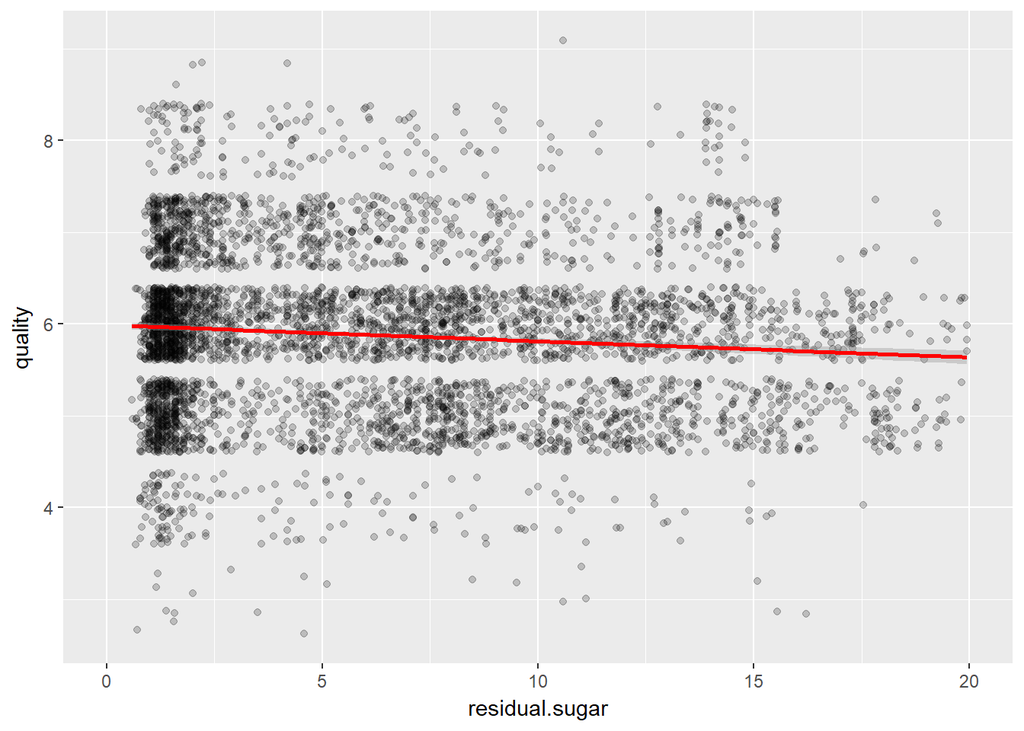

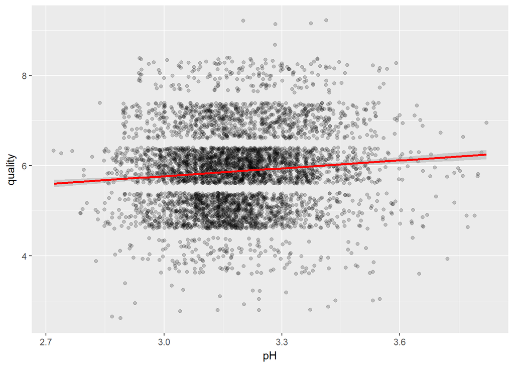

It is not immediately obvious what the relationship is between residual sugar or pH and quality. I can compare the median residual sugar content or median pH against the quality using box plots to see better.

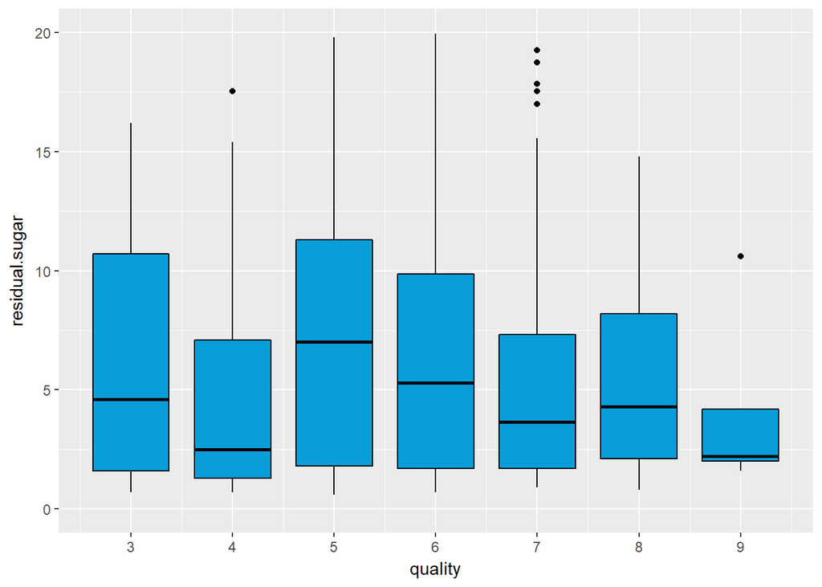

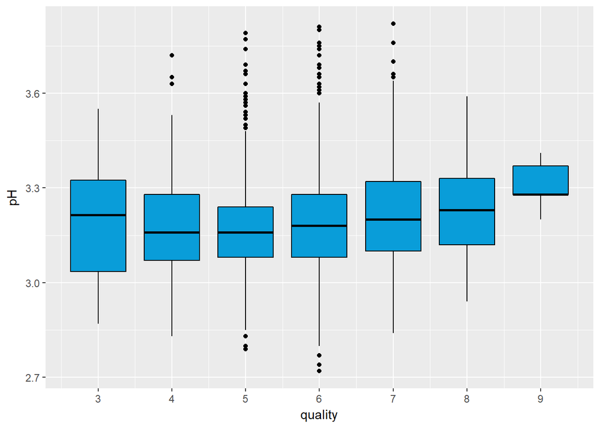

It looks like that residual sugar (sweetness) or pH (acidity) does not differentiate excellent wines from poor wines. So far, it was shown that alcohol content affects quality. I want to explore the other input variables as well. First, I can check the boxplots of acid levels.

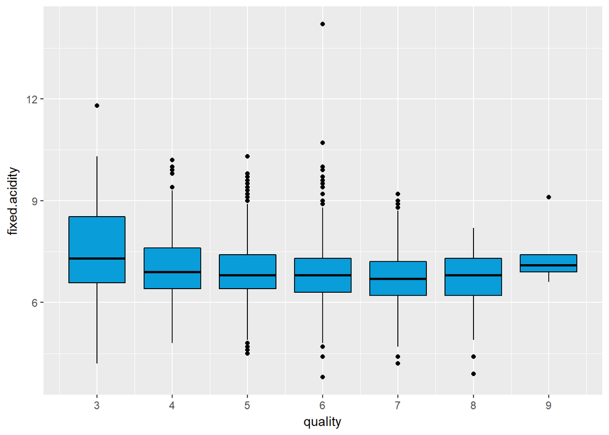

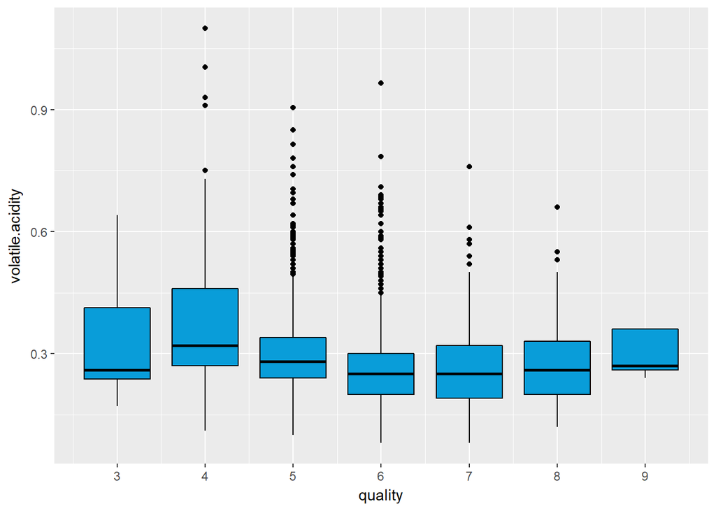

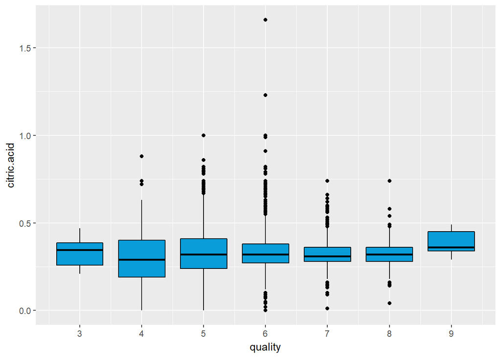

The boxplots show that fixed acidity do not affect the quality. Lower volatile acidity may result to higher quality wines since the variable is the amount of acetic acid in wine. Higher amounts result to unpleasant vinegar taste. On the other hand, higher citric acid content may result to higher quality wines since the variable adds “freshness” and flavor to wines. Since, I know that these acid levels are correlated with pH, it makes sense for me to create a new variable `total_acid` and check against pH.

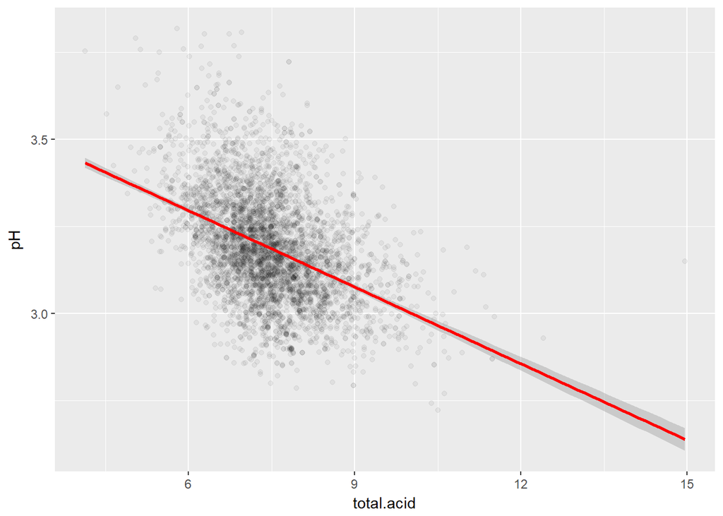

```
##
##  Pearson's product-moment correlation
##
## data:  total.acid and pH
## t = -33.388, df = 4896, p-value < 2.2e-16
## alternative hypothesis: true correlation is not equal to 0
## 95 percent confidence interval:
##  -0.4531918 -0.4075605
## sample estimates:
##        cor
## -0.4306513
```

The new variable has a stronger correlation (-0.431) with pH rather than comparing their individual factors against pH. However, since I know that pH is not a good indicator of wine quality, this new variable will also not be a good indicator. Next, I can check the boxplots of sulfur and its derivatives.

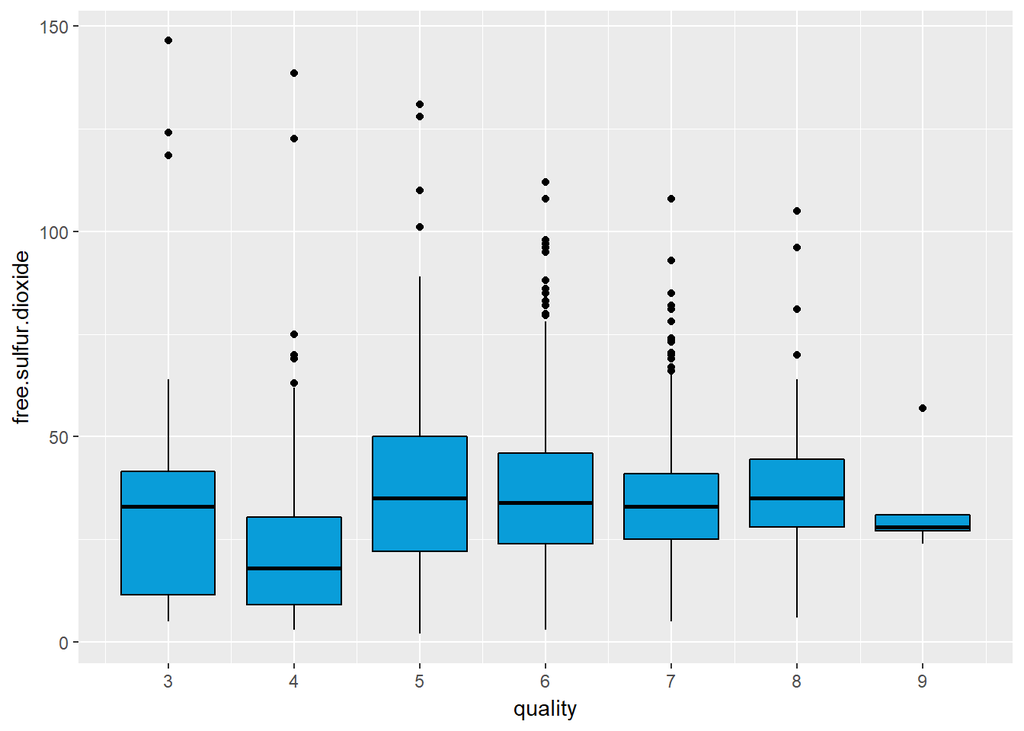

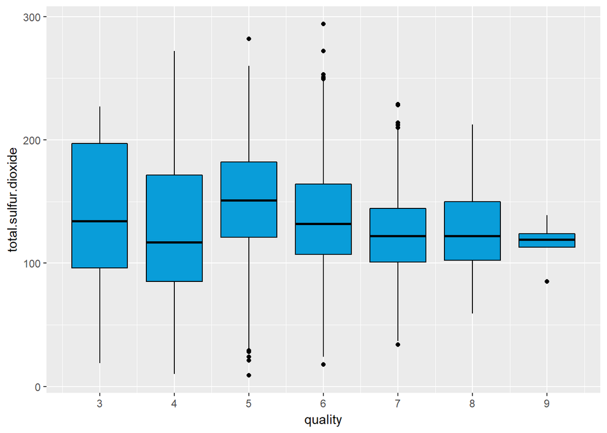